# week2AssignmentEDA

Matthew Onimus

3/19/2020

## Data Introduction

Today we will be exploring a data table in the r package `nycflights13`. This packages contains 5 tables, the one of interst to us will be the flights data. The other 4 tables contain meta information; I may use some of those tables a future exercise. The flights table contains on-time data from all flights departing NYC in 2013 [link](https://cran.r-project.org/web/packages/nycflights13/nycflights13.pdf).

Firstly, lets load the flights table into our environment and take a look at the head and tail.

```r
flights <- nycflights13::flights

# we'll have r do some math for us since we may not now how many observations our data has
datatable(sample_n(flights, size = 300))
```

|  | year | month | day | dep_time | sched_dep_time | dep_delay | arr_time | sched_arr_time | arr_delay | carrier | flight | tailnum | origin | dest | air_time | distance | hour | minute | time_hour |
| --- | --- | --- | --- | --- | --- | --- | --- | --- | --- | --- | --- | --- | --- | --- | --- | --- | --- | --- | --- |
| 1 | 2013 | 11 | 13 | 1444 | 1449 | -5 | 1742 | 1805 | -23 | UA | 1744 | N16732 | LGA | IAH | 195 | 1416 | 14 | 49 | 2013-11-13T19:00:00Z |
| 2 | 2013 | 11 | 17 | 2201 | 2100 | 61 | 17 | 2329 | 48 | B6 | 775 | N318JB | JFK | MSY | 172 | 1182 | 21 | 0 | 2013-11-18T02:00:00Z |
| 3 | 2013 | 9 | 2 | 928 | 936 | -8 | 1142 | 1150 | -8 | EV | 4495 | N13538 | EWR | SAV | 109 | 708 | 9 | 36 | 2013-09-02T13:00:00Z |
| 4 | 2013 | 6 | 11 | 1321 | 1230 | 51 | 1455 | 1401 | 54 | 9E | 3319 | N919XJ | JFK | BUF | 55 | 301 | 12 | 30 | 2013-06-11T16:00:00Z |
| 5 | 2013 | 6 | 19 | 605 | 610 | -5 | 904 | 906 | -2 | B6 | 315 | N615JB | JFK | FLL | 154 | 1069 | 6 | 10 | 2013-06-19T10:00:00Z |
| 6 | 2013 | 5 | 4 | 839 | 759 | 40 | 954 | 915 | 39 | EV | 4233 | N13956 | EWR | BTV | 46 | 266 | 7 | 59 | 2013-05-04T11:00:00Z |
| 7 | 2013 | 9 | 19 | 1815 | 1810 | 5 | 2006 | 1955 | 11 | MQ | 3526 | N519MQ | LGA | CMH | 70 | 479 | 18 | 10 | 2013-09-19T22:00:00Z |
| 8 | 2013 | 3 | 6 | 1603 | 1605 | -2 | 1841 | 1903 | -22 | UA | 1269 | N26208 | EWR | PBI | 140 | 1023 | 16 | 5 | 2013-03-06T21:00:00Z |
| 9 | 2013 | 7 | 29 | 955 | 1000 | -5 | 1214 | 1208 | 6 | EV | 4495 | N12569 | EWR | SAV | 103 | 708 | 10 | 0 | 2013-07-29T14:00:00Z |
| 10 | 2013 | 9 | 26 | 1530 | 1529 | 1 | 1850 | 1847 | 3 | UA | 1554 | N13248 | EWR | SFO | 350 | 2565 | 15 | 29 | 2013-09-26T19:00:00Z |

[output cut: 290 more lines]

The dataset consists of 19 variables and 336776 observations; it is a pretty massive data set. As you can imagine, the number of questions you use this data set to answer is also massive. I will attempt to pull about the delay and arrival delay data based on month to see if month impact either delay situation. I will then attempt to expand upon that is see if carrier plays a role as well. The columns which I will `select` out for this analysis will be `month`, `dep_delay`, `arr_delay`, and `carrier`.

## Let’s Get to Work!

Let’s `select` the columns I will need and save them in their own dataframe.

```r
cleanFlights <- flights %>%
  select(month, dep_delay, arr_delay, carrier)  #just select the columns i care about

summary(cleanFlights)
```

```
##      month          dep_delay         arr_delay          carrier
##  Min.   : 1.000   Min.   : -43.00   Min.   : -86.000   Length:336776
##  1st Qu.: 4.000   1st Qu.:  -5.00   1st Qu.: -17.000   Class :character
##  Median : 7.000   Median :  -2.00   Median :  -5.000   Mode  :character
##  Mean   : 6.549   Mean   :  12.64   Mean   :   6.895
##  3rd Qu.:10.000   3rd Qu.:  11.00   3rd Qu.:  14.000
##  Max.   :12.000   Max.   :1301.00   Max.   :1272.000
##                   NA's   :8255      NA's   :9430
```

### Question 1

Now that the easy part is done, we should probably make some summary statistics and a plot or two to answer my first question: “Does month impact delay times?” **Remember to handle those nasty `NA` values as we go.

```r
monthFlights <- cleanFlights %>%
  mutate(month = as.factor(month)) %>%
  group_by(month) %>%
  summarise(avg_dep_delay = mean(dep_delay, na.rm = TRUE),
            avg_arr_delay = mean(arr_delay, na.rm = TRUE))

datatable(monthFlights)
```

|  | month | avg_dep_delay | avg_arr_delay |
| --- | --- | --- | --- |
| 1 | 1 | 10.0366650303969 | 6.1299719675733 |
| 2 | 2 | 10.816842549599 | 5.6130193553852 |
| 3 | 3 | 13.2270761091052 | 5.80757651781234 |
| 4 | 4 | 13.9380377413058 | 11.1760629806995 |
| 5 | 5 | 12.9868593489888 | 3.52150881683731 |
| 6 | 6 | 20.8463317911434 | 16.4813296398892 |
| 7 | 7 | 21.7277865543268 | 16.711306683632 |
| 8 | 8 | 12.6110398391179 | 6.0406523855891 |
| 9 | 9 | 6.72247621856795 | -4.0183635690485 |
| 10 | 10 | 6.24398841308065 | -0.167062687818855 |

[output cut: 2 more lines]

Well I really thought that the winter months in NYC would have been the worst for both delays, but that is not the case at all. July has the highest average delay for both departures and arrivals. Could be due to the total number of flights in that month (vacations, etc.)? Perhaps we should explore that a little later. For now, there seems to be some correlation between the two delays which means its time to make some plots!

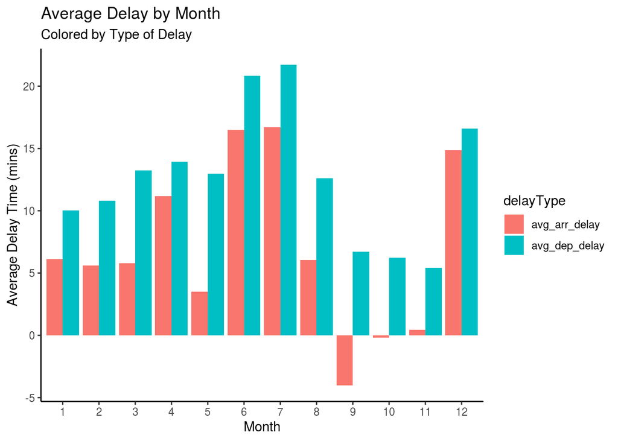

```r
monthFlights %>%
  gather(avg_dep_delay, avg_arr_delay, key = 'delayType', value = 'time') %>%
  ggplot(., aes(x = month, y = time, fill = delayType)) +
  geom_col(position = 'dodge') +
  theme_classic() +
  labs(
    title = "Average Delay by Month",
    subtitle = "Colored by Type of Delay",
    y = "Average Delay Time (mins)",
    x = "Month"
  )
```

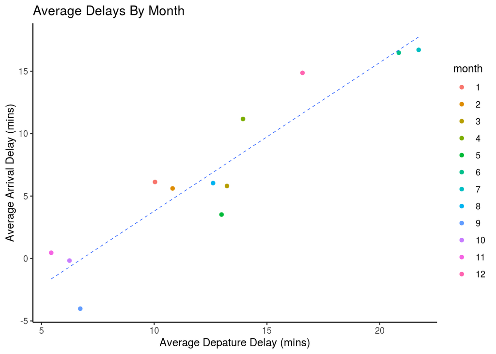

```r
ggplot(monthFlights, aes(x = avg_dep_delay, y = avg_arr_delay)) +
  geom_point(aes(color = month)) +
  geom_smooth(method = 'lm', se = FALSE, size = 0.3, linetype = 'dashed') +
  theme_classic() +
  labs(
    x = "Average Depature Delay (mins)",
    y = "Average Arrival Delay (mins)",
    title = "Average Delays By Month"
  )
```

### Question 2

We need to add a second grouping variable to see if some airline carriers are consistently late or does that fluctate as well.

```r
carrierFlights <- cleanFlights %>%
  mutate(month = as.factor(month),
         carrier = as.factor(carrier)) %>%
  group_by(month, carrier) %>%
  summarise(totalFlights = n(),
            avg_dep_delay = mean(dep_delay, na.rm = TRUE),
            avg_arr_delay = mean(arr_delay, na.rm = TRUE)) %>%
  filter(totalFlights > 1500)

datatable(carrierFlights)
```

|  | month | carrier | totalFlights | avg_dep_delay | avg_arr_delay |
| --- | --- | --- | --- | --- | --- |
| 1 | 1 | 9E | 1573 | 16.8825100133511 | 10.2074324324324 |
| 2 | 1 | AA | 2794 | 6.93235831809872 | 0.982378854625551 |
| 3 | 1 | B6 | 4427 | 9.493435943866 | 4.71719918422842 |
| 4 | 1 | DL | 3690 | 3.84976782299918 | -4.4046511627907 |
| 5 | 1 | EV | 4171 | 24.2288794184006 | 25.1601917255298 |
| 6 | 1 | MQ | 2271 | 6.48549410698096 | 7.88379482523831 |
| 7 | 1 | UA | 4637 | 8.32616720955483 | 3.17559912854031 |
| 8 | 1 | US | 1602 | 1.81736334405145 | 1.43114543114543 |
| 9 | 2 | AA | 2517 | 8.27692307692308 | 1.09378907878283 |
| 10 | 2 | B6 | 4103 | 13.7729113924051 | 12.4793409378961 |

[output cut: 81 more lines]

Time for some plots to see if we can make sense of this data.

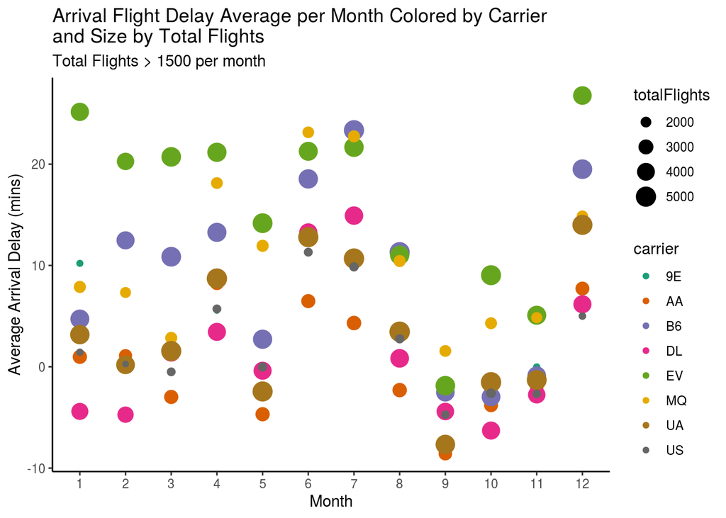

```r
ggplot(carrierFlights, aes(x = month, y = avg_arr_delay, color = carrier, size = totalFlights)) +
  geom_point() +
  scale_color_brewer(palette = 'Dark2') +
  theme_classic() +
  labs(
    title = "Arrival Flight Delay Average per Month Colored by Carrier \nand Size by Total Flights",
    subtitle = "Total Flights > 1500 per month",
    x = "Month",
    y = "Average Arrival Delay (mins)"
  )
```

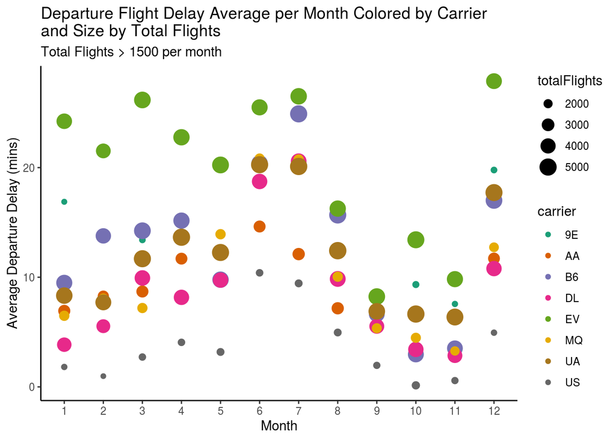

```r
ggplot(carrierFlights, aes(x = month, y = avg_dep_delay, color = carrier, size = totalFlights)) +
  geom_point() +
  scale_color_brewer(palette = 'Dark2') +
  theme_classic() +
  labs(
    title = "Departure Flight Delay Average per Month Colored by Carrier \nand Size by Total Flights",
    subtitle = "Total Flights > 1500 per month",
    x = "Month",
    y = "Average Departure Delay (mins)"
  )
```